# The RSA Algorithm

September 27, 2022

# Symmetry and Asymmetry

## Public Key Cryptosystems

- AES is great, but it is a **symmetric key** cryptosystem; it uses the same key to encrypt as to decrypt.
- Suppose you have thousands of customers, and you want a secure way of collecting credit card information from them: if you want to use AES, you need a secure way of getting each of them a (different) key.
- RSA is a **public key** cryptosystem. The key to encrypt is made public, but the key to decrypt is kept private.

## Public key cryptosystems

Problem: Alice (e.g., a customer with a credit card) would like to send a secret message to Bob (e.g., an online store), but Alice and Bob have never met or exchanged private key information.

## Public key cryptosystems

Problem: Alice (e.g., a customer with a credit card) would like to send a secret message to Bob (e.g., an online store), but Alice and Bob have never met or exchanged private key information.

**Physical analogy:** Lockbox and key

- Alice asks Bob to send her an unlocked lockbox.
- Bob sends the lockbock to Alice, leaves it unlocked, and keeps the key.
- Alice puts her credit card number in the box, locks it, and sends it to Bob.
- Bob receives the lockbox, unlocks it, and gets the credit card number.

In transit, Eve could be in possession of the lockbox, but would not get the credit card number.

## Example: https (Source: [tiptopsecurity.com](https://tiptopsecurity.com/how-does-https-work-rsa-encryption-explained/))

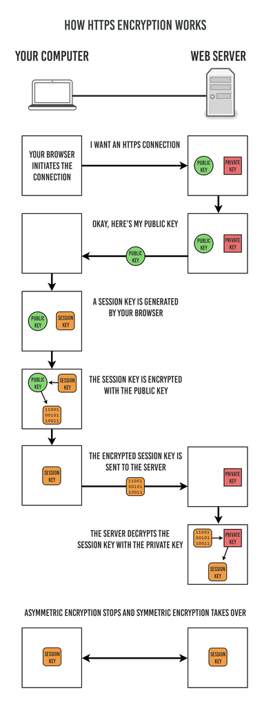

# Prime numbers

## One-way functions

In the natural numbers $\mathbb{N}$,

- Given large primes $p$ and $q$, it is very easy to compute $pq$.
- Given $n = pq$ where $p$ and $q$ are large primes, it is very difficult to compute $p$ and $q$.

Idea behind RSA: If you know $pq$, you can encrypt a message, but you have to know $p$ and $q$ to decrypt the message.

## Group Discussion

> **Without using technology**, compute:

> $3^{100}$ in $\mathbb{Z}_4$

> $3^{100}$ in $\mathbb{Z}_5$

> $3^{100}$ in $\mathbb{Z}_7$

> $3^{100}$ in $\mathbb{Z}_8$

> $3^{100}$ in $\mathbb{Z}_{10}$

> What patterns do you notice?

## Powers of invertible elements in $\mathbb{Z}_n$

Recall, $a$ is invertible in $\mathbb{Z}_n$ if and only if $\gcd(a,n)=1$.

Let $u_1, u_2, \ldots, u_k$ be the distinct invertible elements of $\mathbb{Z}_n$.

Let $a$ be one of the invertible elements, and consider the following sequence in $\mathbb{Z}_n$.
$$au_1, au_2, \ldots, au_k$$

- Every element in this sequence is invertible. (Why?)
- There will be no repeats in this sequence. (Why?)
- The product of this sequence will equal $u_1u_2\cdots u_k$. (Why?)

## Euler’s Theorem

Let $\phi(n)$ be the number of invertible elements in $\mathbb{Z}_n$. We have proved the following theorem.

> **Euler’s Theorem:** If $\gcd(a,n)=1$, then $a^{\phi(n)} \equiv 1 \pmod n$.

The function $\phi$, which counts the number of elements that are relatively prime to $n$, is called the **Euler Phi Function** or the **Euler Totient Function**.

## Corollary: Fermat’s Little Theorem

- **Euler’s Theorem:** If $\gcd(a,n)=1$, then $a^{\phi(n)} \equiv 1 \pmod n$.
- **Fermat’s Little Theorem:** For $p$ prime and $a \neq 0$, $a^{p-1} = 1$ in $\mathbb{Z}_p$.

# RSA

## The RSA algorithm

1. Bob chooses large primes $p$ and $q$ and computes $n=pq$.
2. Bob chooses exponent $e$ relatively prime to $(p-1)(q-1)$.
3. Bob computes $d = e^{-1}$ modulo $(p-1)(q-1)$.
4. Bob makes $n$ and $e$ public, but keeps $p$, $q$, and $d$ secret.
5. Alice codes a plaintext message as a number $m$. She computes $c = m^e \bmod n$ and sends $c$ to Bob.
6. Bob decrypts by computing $m = c^d \bmod n$.

## RSA step 1: choose $p$ and $q$ and compute $n$

```r
p <- 885320963
q <- 238855417
n <- p*q
print(n)
```

```
[1] 2.114637e+17
```

Not good. We need to see more digits.

```r
options(digits=20)
print(n)
```

```
[1] 211463707796206560
```

Still not good. (Why?)

## RSA step 1: choose $p$ and $q$ and use `bigz`

```r
library(gmp) # for big integers
p <- as.bigz("885320963")
q <- as.bigz("238855417")
n <- p*q
print(n)
```

```
Big Integer ('bigz') :
[1] 211463707796206571
```

## RSA step 2: choose an exponent $e$

```r
e <- 9007
```

We should check that $e$ is relatively prime to $(p-1)(q-1)$.

```r
gcd(e, (p-1)*(q-1))
```

```
[1] 1
```

## RSA step 3: Compute $d = e^{-1}$.

```r
gcdex(e,(p-1)*(q-1)) # given in gmp package
```

```
Big Integer ('bigz') object of length 3:
[1] 1                  -95061235518491201 4049
```

So we know that $1 = -95061235518491201e + 4049(p-1)(q-1)$. Therefore set $d = -95061235518491201 \bmod (p-1)(q-1)$ and check that $de \equiv 1 \pmod {(p-1)(q-1)}$.

```r
d <- mod.bigz(gcdex(e,(p-1)*(q-1))[2], (p-1)*(q-1))
cat(paste0("d = ", d, ", de mod (p-1)(q-1) = ", mod.bigz(d*e, (p-1)*(q-1))))
```

```
d = 116402471153538991, de mod (p-1)(q-1) = 1
```

## RSA step 3: Compute $d = e^{-1}$. (easy way)

```r
inv.bigz(e,(p-1)*(q-1)) # given in gmp package
```

```
Big Integer ('bigz') :
[1] 116402471153538991
```

## RSA step 4

Bob makes $n$ and $e$ public:

```
n = 211463707796206571
e = 9007
```

but keeps $p$, $q$, and $d$ secret.

```
p = 885320963
q = 238855417
d = 116402471153538991
```

## RSA step 5: code $m$ and send $c = m^e \bmod n$

We would like to send the message “Cubs!”. Any text message can be coded into a single (big) integer. For example,

```r
#' Convert string to big integer
#'
#' Converts a string to a bigz integer. First the characters of the string are converted to raw, then the
#' raw (hexadecimal) vector is converted to an integer, where the place values of this vector are assigned
#' from right to left.
stringToBigz <- function(txt) {
  nraw <- charToRaw(txt)
  l <- length(nraw)
  return(sum(as.bigz(256)^(l-(1:l))*as.numeric(nraw)))
}
stringToBigz("Cubs!")
```

```
Big Integer ('bigz') :
[1] 289732195105
```

## RSA step 5: code $m$ and send $c = m^e \bmod n$

```r
m <- stringToBigz("Cubs!")
m
```

```
Big Integer ('bigz') :
[1] 289732195105
```

Note that this message better be smaller than $n$. If not, we would use blocks.

Alice, who knows $n$ and $e$, which are public, sends $c = m^e \bmod n$.

```r
c <- mod.bigz(pow.bigz(m,e),n) # Warning: don't do it this way
c
```

```
Big Integer ('bigz') :
[1] 108464973573671852
```

## RSA step 6: compute $c^d \bmod n$

Bob decrypts by computing $m = c^d \bmod n$.

```r
mod.bigz(pow.bigz(c,d),n) # danger!
```

Boom! R dies. (why?)

Fortunately, package `gmp` has a function for computing powers mod $n$.

```r
powm(c,d,n)
```

```
Big Integer ('bigz') :
[1] 289732195105
```

## Convert integer back to text

```r
#' Convert (some) big integers to strings
#'
#' This function is intended to serve as an inverse to the stringToBigz function.
#' If the raw representation of n contains 00's, this function will produce an
#' `embedded nul in string` error. Thus it is not suitable for all integers.
bigzToString <- function(n) {
  numbytes <- ceiling(log2.bigz(n)/8)
  nnumeric <- numeric(numbytes)
  for(i in 0:(numbytes-1)) {
    b <- as.numeric(mod.bigz(n, 256))
    n <- divq.bigz(n, 256)
    nnumeric[numbytes-i] <- b
  }
  return(rawToChar(as.raw(nnumeric)))
}
bigzToString(powm(c,d,n))
```

```
[1] "Cubs!"
```

## Proof that RSA works: why we use $(p-1)(q-1)$

**Euler’s Theorem:** If $\gcd(a,n)=1$, then $a^{\phi(n)} \equiv 1 \pmod n$.

In our case, $n=pq$. How many numbers are relatively prime to $pq$?

- $p, 2p, 3p, \ldots, (q-1)p$ are *not*.
- $q, 2q, 3q, \ldots, (p-1)q$ are *not*.
- Everything else less than $pq$ is relatively prime to $pq$.

$pq-1 - (q-1) - (p -1) = pq - q - p + 1 = (p-1)(q-1)$.

So $\phi(n)=(p-1)(q-1)$.

## Proof that RSA works: how to recover $m$

When Bob decrypts, he computes:

$$\begin{aligned}
c^d \bmod n &= (m^e)^d \bmod n \\
&= m^{de} \bmod n \\
&= m^{1 + k(p-1)(q-1)} \bmod n\\
&= m \cdot \left(m^{(p-1)(q-1)}\right)^k \bmod n \\
& = m \cdot 1^k \\
&= m
\end{aligned}$$

## Practice on a “toy” example (groups)

- Public: modulus: 77, encryption exponent: 13
- Encrypt the plaintext 20.
- Determine the decryption exponent.
- Check that the decryption exponent works.
- Would this example work if the encryption exponent were 3 instead of 13? Try it.

# Some practical considerations

## Computational cost of RSA?

1. Bob chooses large primes $p$ and $q$ and computes $n=pq$.
2. Bob chooses exponent $e$ relatively prime to $(p-1)(q-1)$.
3. Bob computes $d = e^{-1}$ modulo $(p-1)(q-1)$.
4. Bob makes $n$ and $e$ public, but keeps $p$, $q$, and $d$ secret.
5. Alice codes a plaintext message as a number $m$. She computes $c = m^e \bmod n$ and sends $c$ to Bob.
6. Bob decrypts by computing $m = c^d \bmod n$.

## Fast exponentiation

```r
rPower <- function(x, n)
{
  if(n==0) return(1)
  x*rPower(x, n-1)
}

qPower <- function(x, n)
{
  if(n==0) return(1)
  ifelse(n %% 2 == 0, (qPower(x, n/2))^2, x*(qPower(x, n %/% 2))^2)
}
```

For big integers, `powm` is some version of the latter.

## Why does RSA use prime numbers?

Which step of the following derivation relies on $p$ and $q$ being prime?

$$\begin{aligned}
c^d \bmod n &= (m^e)^d \bmod n \\
&= m^{de} \bmod n \\
&= m^{1 + k(p-1)(q-1)} \bmod n\\
&= m \cdot \left(m^{(p-1)(q-1)}\right)^k \bmod n \\
& = m \cdot 1^k \\
&= m
\end{aligned}$$

## Basic prime number facts

- A natural number $n$ is **prime** if it has no divisors other than $n$ and $1$.
- If a number is not prime, it is called **composite.**
- If all of the prime numbers up to $\sqrt{n}$ fail to divide $n$, then $n$ is prime.

Next time we’ll focus on how to deal with big prime numbers.

## How big do the primes need to be?

- Long enough so they can’t be factored.
- Long enough so the blocks aren’t annoyingly small.

```r
factorize("211463707796206571")
```

```
Big Integer ('bigz') object of length 2:
[1] 885320963 238855417
```

## Factorization records?

During 2007-2009, a team of 10 researchers managed to factor one of the RSA challenge numbers:

```r
rsaChallenge <- as.bigz("12301866845301177551304949583849627207728535695953347921973
                22452151726400507263657518745202199786469389956474942774063845925192
                55732630345373154826850791702612214291346167042921431160222124047927
                4737794080665351419597459856902143413")
log2(rsaChallenge)
```

```
[1] 767.66426718447132771
```

```r
log10(rsaChallenge)
```

```
[1] 231.08997102193467299
```

Try `factorize("rsaChallenge")` and see what happens.

## Message/block length can’t exceed modulus

```r
m <- stringToBigz("I would like to send a message that could correspond
                   to a reasonably complicated sentence.")
m
```

```
Big Integer ('bigz') :
[1] 230267646157976665334758755656258279653427770753844931627722…
```

```r
log10(m) ## number of decimal digits in m
```

```
[1] 264.36223292154153341
```

```r
log2(m) ## number of bits in m
```

```
[1] 878.19232876922569631
```

## OpenSSL currently recommends 2048-bit moduli

```r
key <- rsa_keygen()
rsaModulus <- as.list(key)$data$n
rsaModulus
```

```
[b] 224706532695277209277670581200489201774526790130016809832562…
```

```r
str(rsaModulus)
```

```
 'bignum' raw [1:257] 00 b2 00 79 ...
```

(See console.)